# R Assignment - Pizza EDA

today

```r
# 1. Answer each question using in words/paragraph.
# 2. DO NOT use comments inside code blocks (like here) to answer anything. Those are for notes between
# coders/yourself. They will be ignored, and not counted as answers.
# 3. Keep the line/option    knitr::opts_chunk$set(warning = F, results = "hide", message = F)
# You can temporarily turn this on/off and use other option while you are working on the homework if it helps.
# The submitted work should have this option selected instead.
# 4. All charts/graphs/tables should have appropriate captions.
# 5. You may want to use the ezids::outlierKD2 function to handle outliers
# 6. Your grade is also determined by the style. Even if you answers everything correctly, but the html does not look appealing, you will NOT get the full credits. Pay attention to the details that we mentioned in class and in previous sample RMD files. How to use #, ##, ###, ..., bold face, italics, inline codes, LaTeX, tables, ...,  {results = "asis"}, single space vs two spaces at the end of line, ... , use of colors in plots/ggplots, and so forth.
```

# HW Assignment - EDA

This pizza ingredient dataset is from data.world (@sdhilip) The variables are:

| Variable | Definition |
| --- | --- |
| brand | Pizza brand |
| id | ID |
| mois | Amount of water per 100 grams in the sample |
| prot | Amount of protein per 100 grams in the sample |
| fat | Amount of fat per 100 grams in the sample |
| ash | Amount of ash per 100 grams in the sample |
| sodium | Amount of sodium per 100 grams in the sample |
| carb | Amount of carbohydrates per 100 grams in the sample |
| cal | Amount of calories per 100 grams in the sample |

As with all your work in this class, knit the RMD file into HTML, zip it with the RMD, and submit the zip file on Blackboard.

Compose your answers using inline R code instead of using the code-block output as much as you can. Coder’s comments inside code blocks are never graded.

## Pizza Ingredient dataset

### Question 1

**Import the dataset into R.**

```r
pizza = data.frame(read.csv("Pizza.csv"))
```

### Question 2

**How many data points are there?**  
There are 300 observations in the dataset.

### Question 3

**Look at the summary statistics of the dataset.**  
Use the `xkablesummary()` function?

```r
xkablesummary(pizza)
```

Table: Statistics summary.

|  | brand | id | mois | prot | fat | ash | sodium | carb | cal |
| --- | --- | --- | --- | --- | --- | --- | --- | --- | --- |
| Min | Length:300 | Min. :14003 | Min. :25.0 | Min. : 6.98 | Min. : 4.4 | Min. :1.17 | Min. :0.250 | Min. : 0.5 | Min. :2.18 |
| Q1 | Class :character | 1st Qu.:14094 | 1st Qu.:30.9 | 1st Qu.: 8.06 | 1st Qu.:14.8 | 1st Qu.:1.45 | 1st Qu.:0.450 | 1st Qu.: 3.5 | 1st Qu.:2.91 |
| Median | Mode :character | Median :24020 | Median :43.3 | Median :10.44 | Median :17.1 | Median :2.22 | Median :0.490 | Median :23.2 | Median :3.21 |
| Mean | NA | Mean :20841 | Mean :40.9 | Mean :13.37 | Mean :20.2 | Mean :2.63 | Mean :0.669 | Mean :22.9 | Mean :3.27 |
| Q3 | NA | 3rd Qu.:24110 | 3rd Qu.:49.1 | 3rd Qu.:20.02 | 3rd Qu.:21.4 | 3rd Qu.:3.59 | 3rd Qu.:0.703 | 3rd Qu.:41.3 | 3rd Qu.:3.52 |
| Max | NA | Max. :34045 | Max. :57.2 | Max. :28.48 | Max. :47.2 | Max. :5.43 | Max. :1.790 | Max. :48.6 | Max. :5.08 |

### Question 4

**Make Plots - 1**  
For sodium and calorie, make histograms, boxplots (using `ggplot()`), and QQ-plots (just regular `qqnorm()` function). Make sure all plots have appropriate titles, x- and y- labels, units on the axes if applicable. It is also much nicer to add some color to your charts instead of plain old black and white. For chart titles, if no appropriate title you can think of, just use y vs x. Don’t get mixed up (somehow I find up to half of the presentations have the wrong ones). It is NEVER x vs y. **Always y vs x**.

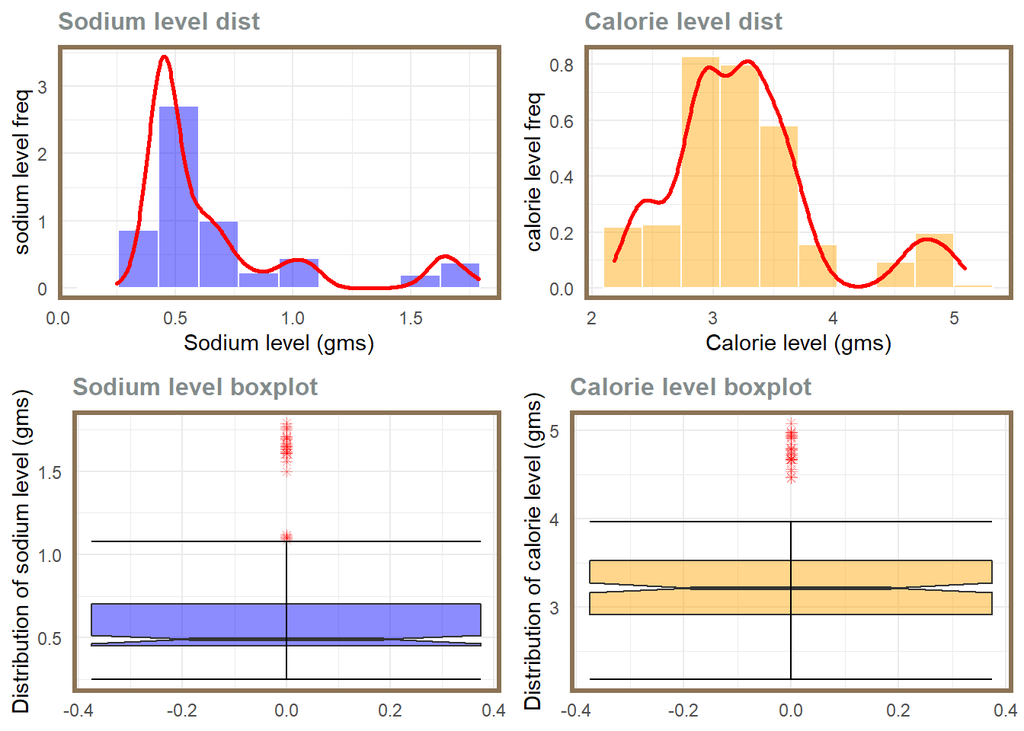

```r
p1 <- ggplot(data=pizza, aes(x=sodium, y=..density..)) +
      geom_histogram(fill='blue', color='white', alpha=0.45, bins=10, aes(y=..density..)) +
      geom_density(color='red', lwd=1 ) +
      xlab('Sodium level (gms)') +
      ylab('sodium level freq') +
      ggtitle(label='Sodium level dist') +
      theme_minimal() +
      theme(plot.title=element_text(family='', face='bold', colour='azure4', size=12),
            panel.border = element_rect(color = "burlywood4", fill=NA, size=2))

p2 <- ggplot(data=pizza, aes(x=cal)) +
      geom_histogram(fill='orange', color='white', alpha=0.45, bins=10, aes(y=..density..)) +
      geom_density(color='red', lwd=1) +
      xlab('Calorie level (gms)') +
      ylab('calorie level freq') +
      ggtitle(label='Calorie level dist') +
      theme_minimal() +
      theme(plot.title=element_text(family='', face='bold', colour='azure4', size=12),
            panel.border = element_rect(color = "burlywood4", fill=NA, size=2))

p3 <- ggplot(data=pizza, aes(y=sodium)) +
      geom_boxplot(fill='blue', alpha=0.45, outlier.color='red', outlier.alpha=0.4, notch=T, notchwidth=0.5, outlier.shape=8) +
      stat_boxplot(geom='errorbar') +
      ggtitle(label='Sodium level boxplot') +
      ylab('Distribution of sodium level (gms)') +
      theme_minimal() +
      theme(plot.title=element_text(family='', face='bold', colour='azure4', size=12),
            panel.border=element_rect(color='burlywood4', fill=NA, size=2))

p4 <- ggplot(data=pizza, aes(y=cal)) +
      geom_boxplot(fill='orange', alpha=0.45, outlier.color='red', outlier.alpha=0.4, notch=T, notchwidth=0.5, outlier.shape=8) +
      stat_boxplot(geom='errorbar') +
      ggtitle(label='Calorie level boxplot') +
      ylab('Distribution of calorie level (gms)') +
      theme_minimal() +
      theme(plot.title=element_text(family='', face='bold', colour='azure4', size=12),
            panel.border=element_rect(color='burlywood4', fill=NA, size=2))

n <- nrow(pizza)
pizza.melted <- reshape(pizza,
                            varying = c("sodium", "cal"),
                        v.names = "value",
                        timevar = "value_type",
                        times = c("sodium", "cal"),
                            new.row.names = 1:(n*2),
                            direction = "long")

bplot_sc <- ggplot(data=pizza.melted, aes(x=value_type, y=value)) +
            geom_boxplot(outlier.shape=8, outlier.color='red', outlier.alpha=0.4, fill=c('orange', 'blue'), alpha=0.4,width=0.3)+
            stat_boxplot(geom='errorbar')+
            ggtitle('Comparison of calorie and sodium level distribution')+
            xlab('Nutrient type')+
            ylab('Distribution of nutrient value (gms)s')+
            theme_minimal()+
            theme(plot.title=element_text(family='', face='bold', colour='azure4', size=12),
                  panel.border=element_rect(color='burlywood4', fill=NA, size=2))

bplot_sod_brand <- ggplot(data=pizza, aes(x=brand, y=sodium, color=brand, fill=brand)) +
                   geom_boxplot(alpha=0.45, outlier.color='red', outlier.alpha=0.4, notch=T, notchwidth=0.5, outlier.shape=8) +
                   #geom_jitter() + # This obfuscates important information
                   stat_boxplot(geom='errorbar') +
                   ggtitle(label='Boxplot of sodium level in pizza by different brands') +
                   ylab('sodium level (gms) dist') +
                   theme_minimal() +
                   theme(plot.title=element_text(family='', face='bold', colour='azure4', size=12),
                         panel.border=element_rect(color='burlywood4', fill=NA, size=2))

bplot_cal_brand <- ggplot(data=pizza, aes(x=brand, y=cal, color=brand, fill=brand)) +
                   geom_boxplot(alpha=0.45, outlier.color='red', outlier.alpha=0.4, notch=T, notchwidth=0.5, outlier.shape=8) +
                   #geom_jitter() + # This obfuscates important information
                   stat_boxplot(geom='errorbar') +
                   ggtitle(label='Boxplot of calorie level in pizza by different brands') +
                   ylab('calorie level (gms)') +
                   theme_minimal() +
                   theme(plot.title=element_text(family='', face='bold', colour='azure4', size=12),
                         panel.border=element_rect(color='burlywood4', fill=NA, size=2))

grid.arrange(p1, p2, p3, p4, nrow=2)
```

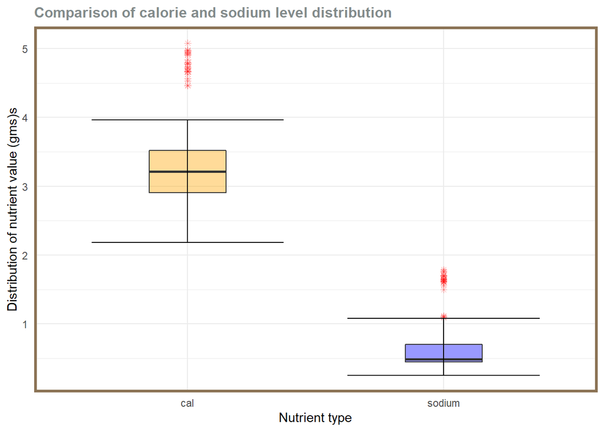

```r
bplot_sc
```

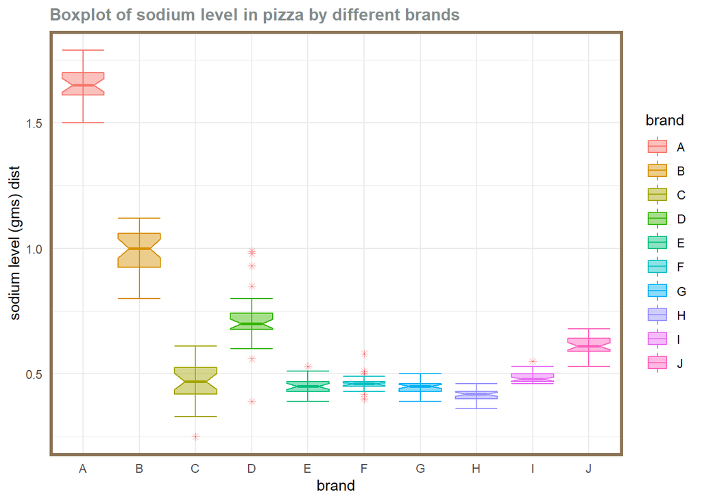

```r
bplot_sod_brand
```

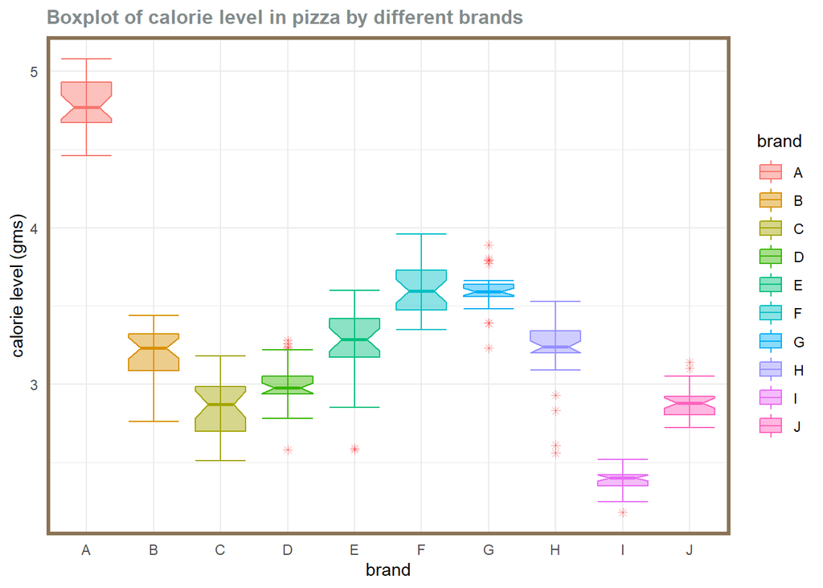

```r
bplot_cal_brand
```

```r
# grid.arrange(bplot_sc, bplot_brand, nrow=2, ncol=1)
```

#### **Normality test**

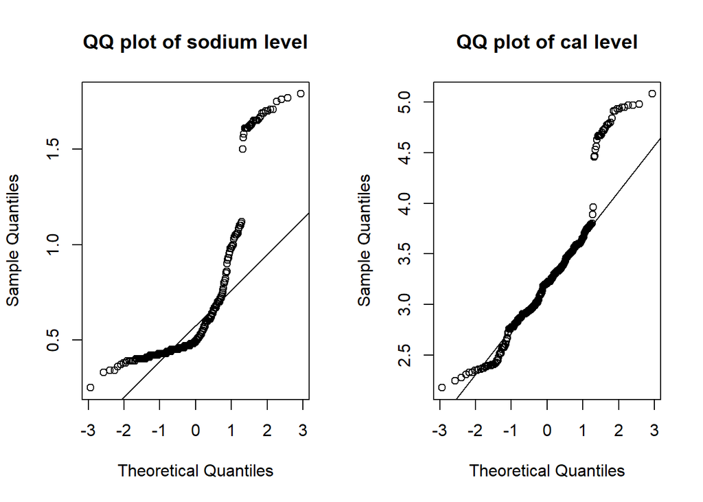

```r
make_qqplot <- function(df, cnames, df2=NULL)
{
  n_cols <- length(cnames)
  if(is.null(df2))
  {
    par(mfrow=c(1, n_cols))
  }
  else
  {
    par(mfrow=c(n_cols, 2))
  }


  for(i in 1:n_cols){
    cname <- cnames[i]
    label <- sprintf("QQ plot of %s level", cname)
    qqnorm(df[, cname], main=label)
    qqline(df[, cname])

    if(!is.null(df2))
    {
      qqnorm(df2[, cname], main=label)
      qqline(df2[, cname])
    }
  }
}

make_qqplot(pizza, c('sodium', 'cal'))
```

### Question 5

**Make Plots - 2**  
Making a scatterplot (using `ggplot()`), between sodium and calorie, color by the brand. As always, give the plot appropriate title, axis labels, and make it look good.

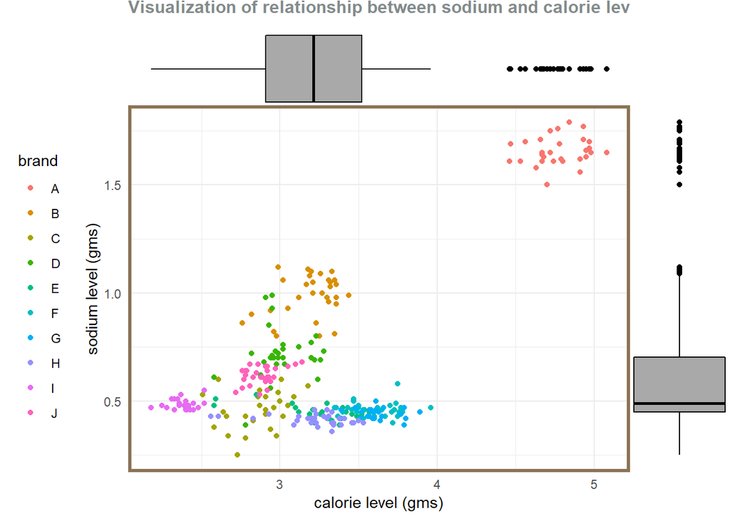

```r
p_cal_sod1 <- ggplot(pizza, aes(x=cal, y=sodium, color=brand)) +
                     geom_point() +
                     xlab('calorie level (gms)') +
                     ylab('sodium level (gms)') +
                     ggtitle(label='Visualization of relationship between sodium and calorie level') +
                     theme_minimal() +
                     theme(plot.title=element_text(family='', face='bold', colour='azure4', size=12),
                           panel.border=element_rect(color='burlywood4', fill=NA, size=2),
                           legend.position='left')
p_cal_sod1 <- ggMarginal(p_cal_sod1, type='boxplot', fill='darkgray')
p_cal_sod1
```

### Question 6

**Make Plots - 3**  
Making another scatterplot (using `ggplot()`), between sodium and calorie, color by protein. /what major difference do you see between this and the previous scatterplot?

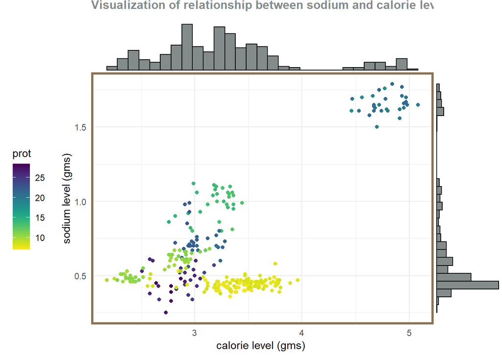

```r
library(viridis)
p_cal_sod2 <- ggplot(pizza, aes(x=cal, y=sodium, color=prot)) +
                     geom_point() +
                     scale_color_viridis(discrete = F, direction=-1)+
                     scale_fill_viridis(discrete = F)+
                     xlab('calorie level (gms) ') +
                     ylab('sodium level (gms)') +
                     ggtitle(label='Visualization of relationship between sodium and calorie level') +
                     theme_minimal() +
                     theme(plot.title=element_text(family='', face='bold', colour='azure4', size=12),
                           panel.border=element_rect(color='burlywood4', fill=NA, size=2),
                           legend.position='left')
p_cal_sod2 <- ggMarginal(p_cal_sod2, type='histogram', fill='azure4')
p_cal_sod2
```

### Question 7

**Make Plots - 4**  
This time, make a plot with sodium as y, and brand as x. (What kind of plot would you choose?)  
Ans:  
*I believe you are referring to boxplot with x as brand, something I have done before this question. However, I will add that to another plot that I think would be also useful. A quick note, for the first plot, the red represents high calorie level while the blue represents less than or equal to average calorie. It appears it is an internal bug with ggplot not to show legend while using grouping*

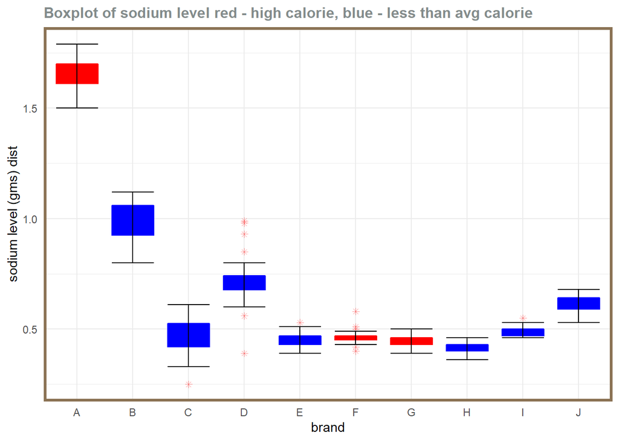

```r
library(dplyr)
total_cal_mean <- mean(pizza$cal)
by_brand <- pizza %>% group_by(brand)
mean_cal <- by_brand %>% summarise(m_cal = mean(cal))
mean_cal <- mean_cal$m_cal
for(i in 1:length(mean_cal))
{
  if(mean_cal[i] > total_cal_mean)
  {
    mean_cal[i] <- "red" # High cal
  }
  else
  {
    mean_cal[i] <- "blue" # Low cal
  }
}

scatter_brand <- ggplot(pizza, aes(x=brand, y=sodium, color=cal)) +
                 geom_point(alpha=0.5) +
                 xlab('Brand') +
                 ylab('Sodium level (gms)') +
                 ggtitle('Visualization of sodium level in each brand along with calorie info') +
                 theme_minimal() +
                 theme(plot.title=element_text(family='', face='bold', colour='azure4', size=12),
                       panel.border=element_rect(color='burlywood4', fill=NA, size=2))

ggplot(data=pizza, aes(x=brand, y=sodium)) +
geom_boxplot(fill=mean_cal, color=mean_cal, outlier.color='red', outlier.alpha=0.4,  outlier.shape=8) +
#geom_jitter() + # This obfuscates important information
stat_boxplot(geom='errorbar') +
ggtitle(label='Boxplot of sodium level red - high calorie, blue - less than avg calorie') +
ylab('sodium level (gms) dist') +
theme_minimal() +
# guides(fill = guide_legend(override.aes = list(linetype = 0, shape='')) +
theme(legend.position = 'right',
      plot.title=element_text(family='', face='bold', colour='azure4', size=12),
      panel.border=element_rect(color='burlywood4', fill=NA, size=2))
```

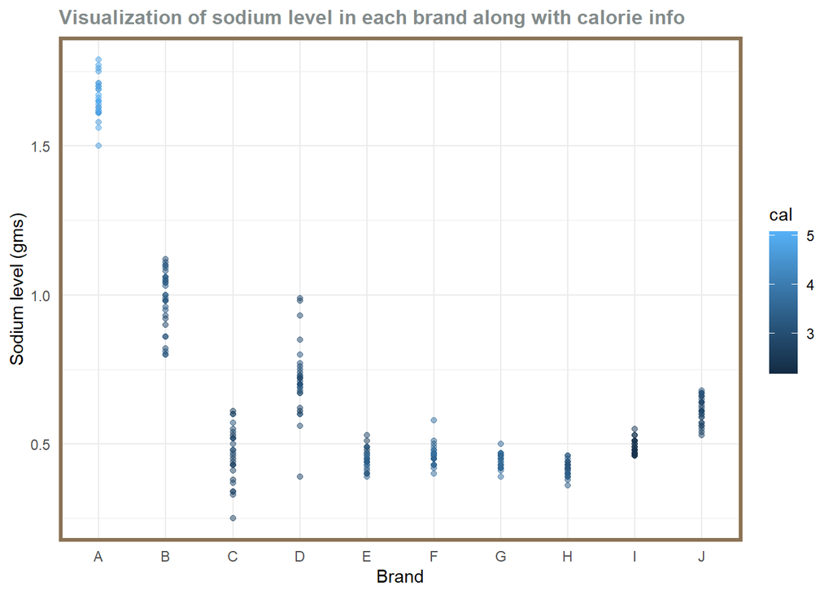

```r
# bplot_sod_brand
scatter_brand
```

```r
# grid.arrange(bplot_sod_brand, scatter_brand, nrow=2 )
```

### Question 8

**Outliers**  
Use the `ezids::outlierKD2()` function to remove the outliers for sodium, then run the function again to remove outliers on calories. Re-do the QQ-plots for these two variables. Do you see much improvements?

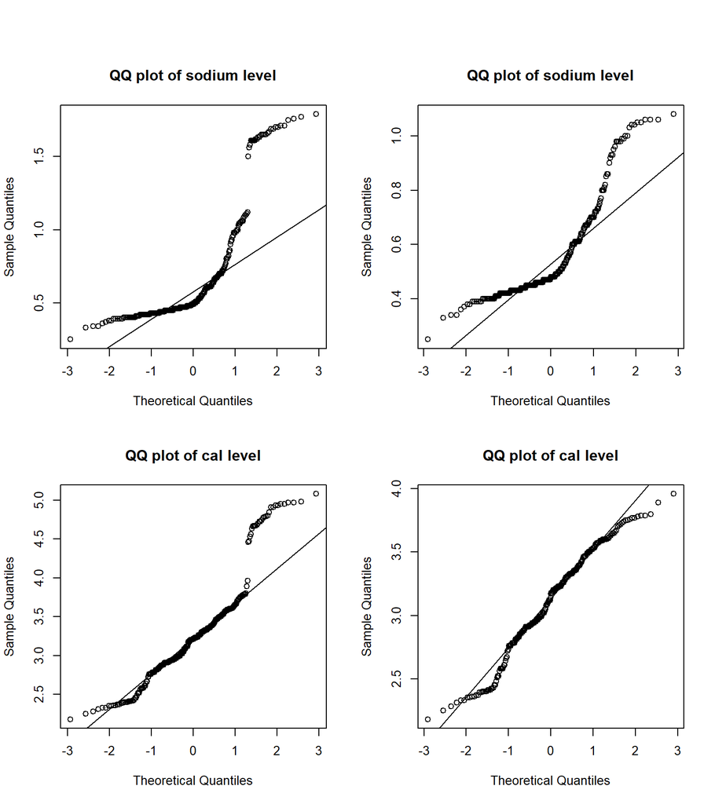

```r
pizza.filtered1 <- ezids::outlierKD2(df=pizza, var=sodium, rm=T, boxplt=F, histogram=F, qqplt=F)
pizza.filtered2 <- ezids::outlierKD2(df=pizza.filtered1, var=cal, rm=T, boxplt=F, histogram=F, qqplt=F)
make_qqplot(pizza, c('sodium', 'cal'), pizza.filtered2)
```

*Pizza with outliers to the left, and clean version to the right* In terms of improvements, I can only spot calorie to be approximately normal, whereas with sodium, there is a systematic departure from linearity.